# Risk Factor Analysis

## Outcome Variable

**Outcome Variable:** stunted

## Predictor Variables

**Intervention Variable:** exclfeed6

**Adjustment Set:**

- arm
- sex
- W_mage
- meducyrs
- feducyrs
- hhwealth_quart
- hfoodsec
- W_mhtcm
- vagbrth
- W_gagebrth
- W_birthwt
- W_birthlen
- W_nrooms
- W_nchldlt5
- month
- brthmon
- W_parity
- impfloor
- impsan
- safeh20
- delta_W_mage
- delta_meducyrs
- delta_feducyrs
- delta_hhwealth_quart
- delta_hfoodsec
- delta_W_mhtcm
- delta_vagbrth
- delta_W_gagebrth
- delta_W_birthwt
- delta_W_birthlen
- delta_W_nrooms
- delta_W_nchldlt5
- delta_month
- delta_brthmon
- delta_W_parity
- delta_impfloor
- delta_impsan
- delta_safeh20

## Stratifying Variables

The analysis was stratified on these variable(s):

- agecat
- studyid
- country

## Data Summary

| agecat | studyid | country | exclfeed6 | stunted | n_cell | n |
| --- | --- | --- | --- | --- | --- | --- |
| Birth | ki0047075b-MAL-ED | BANGLADESH | 1 | 0 | 46 | 231 |
| Birth | ki0047075b-MAL-ED | BANGLADESH | 1 | 1 | 10 | 231 |
| Birth | ki0047075b-MAL-ED | BANGLADESH | 0 | 0 | 146 | 231 |
| Birth | ki0047075b-MAL-ED | BANGLADESH | 0 | 1 | 29 | 231 |
| Birth | ki0047075b-MAL-ED | BRAZIL | 1 | 0 | 10 | 175 |
| Birth | ki0047075b-MAL-ED | BRAZIL | 1 | 1 | 2 | 175 |
| Birth | ki0047075b-MAL-ED | BRAZIL | 0 | 0 | 148 | 175 |
| Birth | ki0047075b-MAL-ED | BRAZIL | 0 | 1 | 15 | 175 |
| Birth | ki0047075b-MAL-ED | INDIA | 1 | 0 | 2 | 190 |
| Birth | ki0047075b-MAL-ED | INDIA | 1 | 1 | 3 | 190 |
| Birth | ki0047075b-MAL-ED | INDIA | 0 | 0 | 157 | 190 |
| Birth | ki0047075b-MAL-ED | INDIA | 0 | 1 | 28 | 190 |
| Birth | ki0047075b-MAL-ED | NEPAL | 1 | 0 | 11 | 170 |
| Birth | ki0047075b-MAL-ED | NEPAL | 1 | 1 | 0 | 170 |
| Birth | ki0047075b-MAL-ED | NEPAL | 0 | 0 | 141 | 170 |
| Birth | ki0047075b-MAL-ED | NEPAL | 0 | 1 | 18 | 170 |
| Birth | ki0047075b-MAL-ED | PERU | 1 | 0 | 8 | 256 |
| Birth | ki0047075b-MAL-ED | PERU | 1 | 1 | 2 | 256 |
| Birth | ki0047075b-MAL-ED | PERU | 0 | 0 | 219 | 256 |
| Birth | ki0047075b-MAL-ED | PERU | 0 | 1 | 27 | 256 |
| Birth | ki0047075b-MAL-ED | SOUTH AFRICA | 1 | 0 | 0 | 211 |
| Birth | ki0047075b-MAL-ED | SOUTH AFRICA | 1 | 1 | 0 | 211 |
| Birth | ki0047075b-MAL-ED | SOUTH AFRICA | 0 | 0 | 189 | 211 |
| Birth | ki0047075b-MAL-ED | SOUTH AFRICA | 0 | 1 | 22 | 211 |
| Birth | ki0047075b-MAL-ED | TANZANIA, UNITED REPUBLIC OF | 1 | 0 | 1 | 119 |
| Birth | ki0047075b-MAL-ED | TANZANIA, UNITED REPUBLIC OF | 1 | 1 | 0 | 119 |
| Birth | ki0047075b-MAL-ED | TANZANIA, UNITED REPUBLIC OF | 0 | 0 | 102 | 119 |
| Birth | ki0047075b-MAL-ED | TANZANIA, UNITED REPUBLIC OF | 0 | 1 | 16 | 119 |
| Birth | ki1000108-CMC-V-BCS-2002 | INDIA | 1 | 0 | 7 | 7 |
| Birth | ki1000108-CMC-V-BCS-2002 | INDIA | 1 | 1 | 0 | 7 |

[output cut: 158 more lines]

The following strata were considered:

- agecat: 24 months, studyid: ki0047075b-MAL-ED, country: BANGLADESH
- agecat: 24 months, studyid: ki0047075b-MAL-ED, country: BRAZIL
- agecat: 24 months, studyid: ki0047075b-MAL-ED, country: INDIA
- agecat: 24 months, studyid: ki0047075b-MAL-ED, country: NEPAL
- agecat: 24 months, studyid: ki0047075b-MAL-ED, country: PERU
- agecat: 24 months, studyid: ki0047075b-MAL-ED, country: SOUTH AFRICA
- agecat: 24 months, studyid: ki0047075b-MAL-ED, country: TANZANIA, UNITED REPUBLIC OF
- agecat: 24 months, studyid: ki1000108-CMC-V-BCS-2002, country: INDIA
- agecat: 24 months, studyid: ki1000108-IRC, country: INDIA
- agecat: 24 months, studyid: ki1017093b-PROVIDE, country: BANGLADESH
- agecat: 24 months, studyid: ki1101329-Keneba, country: GAMBIA
- agecat: 24 months, studyid: ki1113344-GMS-Nepal, country: NEPAL
- agecat: 24 months, studyid: ki1148112-LCNI-5, country: MALAWI
- agecat: 24 months, studyid: kiGH5241-JiVitA-3, country: BANGLADESH
- agecat: 24 months, studyid: kiGH5241-JiVitA-4, country: BANGLADESH
- agecat: 6 months, studyid: ki0047075b-MAL-ED, country: BANGLADESH
- agecat: 6 months, studyid: ki0047075b-MAL-ED, country: BRAZIL
- agecat: 6 months, studyid: ki0047075b-MAL-ED, country: INDIA
- agecat: 6 months, studyid: ki0047075b-MAL-ED, country: NEPAL
- agecat: 6 months, studyid: ki0047075b-MAL-ED, country: PERU
- agecat: 6 months, studyid: ki0047075b-MAL-ED, country: SOUTH AFRICA
- agecat: 6 months, studyid: ki0047075b-MAL-ED, country: TANZANIA, UNITED REPUBLIC OF
- agecat: 6 months, studyid: ki1000108-CMC-V-BCS-2002, country: INDIA
- agecat: 6 months, studyid: ki1000108-IRC, country: INDIA
- agecat: 6 months, studyid: ki1000109-EE, country: PAKISTAN
- agecat: 6 months, studyid: ki1000304b-SAS-CompFeed, country: INDIA
- agecat: 6 months, studyid: ki1000304b-SAS-FoodSuppl, country: INDIA
- agecat: 6 months, studyid: ki1017093b-PROVIDE, country: BANGLADESH
- agecat: 6 months, studyid: ki1101329-Keneba, country: GAMBIA
- agecat: 6 months, studyid: ki1113344-GMS-Nepal, country: NEPAL
- agecat: 6 months, studyid: ki1148112-LCNI-5, country: MALAWI
- agecat: 6 months, studyid: kiGH5241-JiVitA-3, country: BANGLADESH
- agecat: 6 months, studyid: kiGH5241-JiVitA-4, country: BANGLADESH
- agecat: Birth, studyid: ki0047075b-MAL-ED, country: BANGLADESH
- agecat: Birth, studyid: ki0047075b-MAL-ED, country: BRAZIL
- agecat: Birth, studyid: ki0047075b-MAL-ED, country: INDIA
- agecat: Birth, studyid: ki0047075b-MAL-ED, country: NEPAL
- agecat: Birth, studyid: ki0047075b-MAL-ED, country: PERU
- agecat: Birth, studyid: ki0047075b-MAL-ED, country: SOUTH AFRICA
- agecat: Birth, studyid: ki0047075b-MAL-ED, country: TANZANIA, UNITED REPUBLIC OF
- agecat: Birth, studyid: ki1000108-CMC-V-BCS-2002, country: INDIA
- agecat: Birth, studyid: ki1000108-IRC, country: INDIA
- agecat: Birth, studyid: ki1000109-EE, country: PAKISTAN
- agecat: Birth, studyid: ki1000304b-SAS-CompFeed, country: INDIA
- agecat: Birth, studyid: ki1101329-Keneba, country: GAMBIA
- agecat: Birth, studyid: kiGH5241-JiVitA-3, country: BANGLADESH
- agecat: Birth, studyid: kiGH5241-JiVitA-4, country: BANGLADESH

### Dropped Strata

Some strata were dropped due to rare outcomes:

- agecat: Birth, studyid: ki0047075b-MAL-ED, country: BRAZIL
- agecat: Birth, studyid: ki0047075b-MAL-ED, country: INDIA
- agecat: Birth, studyid: ki0047075b-MAL-ED, country: NEPAL
- agecat: Birth, studyid: ki0047075b-MAL-ED, country: PERU
- agecat: Birth, studyid: ki0047075b-MAL-ED, country: SOUTH AFRICA
- agecat: Birth, studyid: ki0047075b-MAL-ED, country: TANZANIA, UNITED REPUBLIC OF
- agecat: Birth, studyid: ki1000108-CMC-V-BCS-2002, country: INDIA
- agecat: Birth, studyid: ki1000108-IRC, country: INDIA
- agecat: Birth, studyid: ki1000109-EE, country: PAKISTAN
- agecat: Birth, studyid: ki1000304b-SAS-CompFeed, country: INDIA
- agecat: 6 months, studyid: ki0047075b-MAL-ED, country: BRAZIL
- agecat: 6 months, studyid: ki0047075b-MAL-ED, country: INDIA
- agecat: 6 months, studyid: ki0047075b-MAL-ED, country: NEPAL
- agecat: 6 months, studyid: ki0047075b-MAL-ED, country: PERU
- agecat: 6 months, studyid: ki0047075b-MAL-ED, country: SOUTH AFRICA
- agecat: 6 months, studyid: ki0047075b-MAL-ED, country: TANZANIA, UNITED REPUBLIC OF
- agecat: 6 months, studyid: ki1000108-CMC-V-BCS-2002, country: INDIA
- agecat: 6 months, studyid: ki1000108-IRC, country: INDIA
- agecat: 6 months, studyid: ki1000304b-SAS-FoodSuppl, country: INDIA
- agecat: 24 months, studyid: ki0047075b-MAL-ED, country: BRAZIL
- agecat: 24 months, studyid: ki0047075b-MAL-ED, country: INDIA
- agecat: 24 months, studyid: ki0047075b-MAL-ED, country: NEPAL
- agecat: 24 months, studyid: ki0047075b-MAL-ED, country: PERU
- agecat: 24 months, studyid: ki0047075b-MAL-ED, country: SOUTH AFRICA
- agecat: 24 months, studyid: ki0047075b-MAL-ED, country: TANZANIA, UNITED REPUBLIC OF
- agecat: 24 months, studyid: ki1000108-CMC-V-BCS-2002, country: INDIA
- agecat: 24 months, studyid: ki1000108-IRC, country: INDIA

## Methods Detail

We’re interested in the causal parameters $E[Y_a]$ for all values of $a \in \mathcal{A}$. These parameters represent the mean outcome if, possibly contrary to fact, we intervened to set all units to have $A=a$. Under the randomization and positivity assumptions, these are identified by the statistical parameters $\psi_a=E_W[E_{Y|A,W}(Y|A=a,W)]$. In addition, we’re interested in the mean of $Y$, $E[Y]$ under no intervention (the observed mean). We will estimate these parameters by using SuperLearner to fit the relevant likelihood factors – $E_{Y|A,W}(Y|A=a,W)$ and $p(A=a|W)$, and then updating our likelihood fit using a joint TMLE.

For unadjusted analyses ($W=\{\}$), initial likelihoods were estimated using Lrnr_glm to estimate the simple $E(Y|A)$ and Lrnr_mean to estimate $p(A)$. For adjusted analyses, a small library containing Lrnr_glmnet, Lrnr_xgboost, and Lrnr_mean was used.

Having estimated these parameters, we will then use the delta method to estimate relative risks and attributable risks relative to a prespecified baseline level of $A$.

# Results Detail

## Results Plots

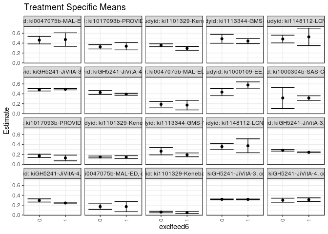

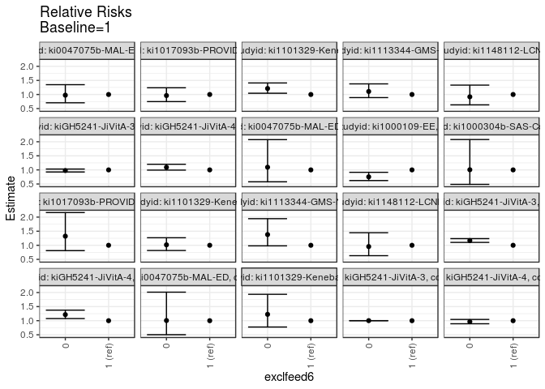

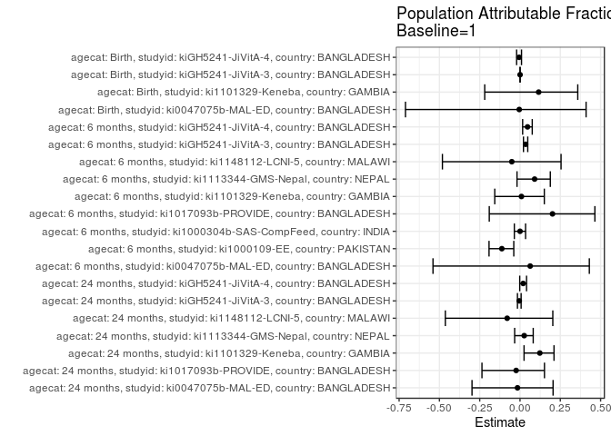

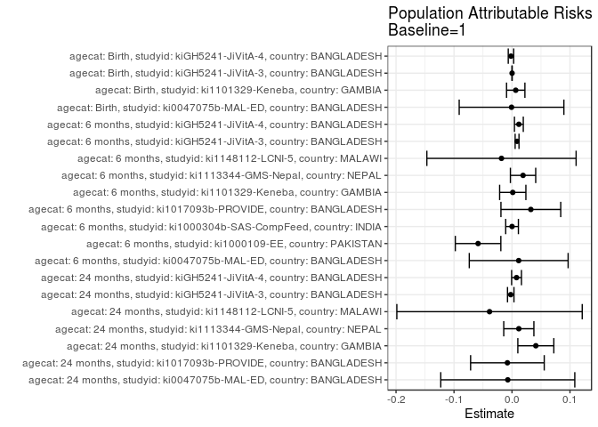

## Results Table

### Parameter: TSM

| agecat | studyid | country | intervention_level | baseline_level | estimate | ci_lower | ci_upper |
| --- | --- | --- | --- | --- | --- | --- | --- |
| Birth | ki0047075b-MAL-ED | BANGLADESH | 1 | NA | 0.1696216 | 0.0664010 | 0.2728422 |
| Birth | ki0047075b-MAL-ED | BANGLADESH | 0 | NA | 0.1706141 | 0.1145202 | 0.2267080 |
| Birth | ki1101329-Keneba | GAMBIA | 1 | NA | 0.0492382 | 0.0299973 | 0.0684790 |
| Birth | ki1101329-Keneba | GAMBIA | 0 | NA | 0.0603240 | 0.0452612 | 0.0753869 |
| Birth | kiGH5241-JiVitA-3 | BANGLADESH | 1 | NA | 0.3164921 | 0.3088811 | 0.3241031 |
| Birth | kiGH5241-JiVitA-3 | BANGLADESH | 0 | NA | 0.3170420 | 0.3094335 | 0.3246505 |
| Birth | kiGH5241-JiVitA-4 | BANGLADESH | 1 | NA | 0.3107671 | 0.2736195 | 0.3479146 |
| Birth | kiGH5241-JiVitA-4 | BANGLADESH | 0 | NA | 0.2997278 | 0.2587281 | 0.3407275 |
| 6 months | ki0047075b-MAL-ED | BANGLADESH | 1 | NA | 0.1714210 | 0.0742140 | 0.2686279 |
| 6 months | ki0047075b-MAL-ED | BANGLADESH | 0 | NA | 0.1875879 | 0.1305571 | 0.2446187 |
| 6 months | ki1000109-EE | PAKISTAN | 1 | NA | 0.5773138 | 0.5136987 | 0.6409289 |
| 6 months | ki1000109-EE | PAKISTAN | 0 | NA | 0.4348717 | 0.3611998 | 0.5085436 |
| 6 months | ki1000304b-SAS-CompFeed | INDIA | 1 | NA | 0.3139842 | 0.2679102 | 0.3600581 |
| 6 months | ki1000304b-SAS-CompFeed | INDIA | 0 | NA | 0.3157895 | 0.1014523 | 0.5301266 |
| 6 months | ki1017093b-PROVIDE | BANGLADESH | 1 | NA | 0.1287450 | 0.0711624 | 0.1863276 |
| 6 months | ki1017093b-PROVIDE | BANGLADESH | 0 | NA | 0.1704036 | 0.1356393 | 0.2051678 |
| 6 months | ki1101329-Keneba | GAMBIA | 1 | NA | 0.1464794 | 0.1189256 | 0.1740331 |
| 6 months | ki1101329-Keneba | GAMBIA | 0 | NA | 0.1488861 | 0.1299859 | 0.1677862 |
| 6 months | ki1113344-GMS-Nepal | NEPAL | 1 | NA | 0.1915511 | 0.1529903 | 0.2301119 |
| 6 months | ki1113344-GMS-Nepal | NEPAL | 0 | NA | 0.2645386 | 0.1912298 | 0.3378475 |
| 6 months | ki1148112-LCNI-5 | MALAWI | 1 | NA | 0.3747523 | 0.2332165 | 0.5162880 |
| 6 months | ki1148112-LCNI-5 | MALAWI | 0 | NA | 0.3578513 | 0.2950269 | 0.4206758 |
| 6 months | kiGH5241-JiVitA-3 | BANGLADESH | 1 | NA | 0.2420764 | 0.2333129 | 0.2508400 |
| 6 months | kiGH5241-JiVitA-3 | BANGLADESH | 0 | NA | 0.2827231 | 0.2679783 | 0.2974678 |
| 6 months | kiGH5241-JiVitA-4 | BANGLADESH | 1 | NA | 0.2426727 | 0.2266052 | 0.2587403 |
| 6 months | kiGH5241-JiVitA-4 | BANGLADESH | 0 | NA | 0.2950066 | 0.2625508 | 0.3274623 |
| 24 months | ki0047075b-MAL-ED | BANGLADESH | 1 | NA | 0.4713903 | 0.3355064 | 0.6072743 |
| 24 months | ki0047075b-MAL-ED | BANGLADESH | 0 | NA | 0.4596253 | 0.3833302 | 0.5359204 |
| 24 months | ki1017093b-PROVIDE | BANGLADESH | 1 | NA | 0.3371886 | 0.2620936 | 0.4122836 |
| 24 months | ki1017093b-PROVIDE | BANGLADESH | 0 | NA | 0.3244271 | 0.2811864 | 0.3676678 |
| 24 months | ki1101329-Keneba | GAMBIA | 1 | NA | 0.2933332 | 0.2551950 | 0.3314714 |
| 24 months | ki1101329-Keneba | GAMBIA | 0 | NA | 0.3558792 | 0.3266824 | 0.3850759 |
| 24 months | ki1113344-GMS-Nepal | NEPAL | 1 | NA | 0.4403210 | 0.3890093 | 0.4916328 |
| 24 months | ki1113344-GMS-Nepal | NEPAL | 0 | NA | 0.4875345 | 0.3972893 | 0.5777797 |
| 24 months | ki1148112-LCNI-5 | MALAWI | 1 | NA | 0.5255146 | 0.3486714 | 0.7023577 |
| 24 months | ki1148112-LCNI-5 | MALAWI | 0 | NA | 0.4821429 | 0.4036093 | 0.5606766 |
| 24 months | kiGH5241-JiVitA-3 | BANGLADESH | 1 | NA | 0.4929254 | 0.4786872 | 0.5071636 |
| 24 months | kiGH5241-JiVitA-3 | BANGLADESH | 0 | NA | 0.4814316 | 0.4572753 | 0.5055879 |
| 24 months | kiGH5241-JiVitA-4 | BANGLADESH | 1 | NA | 0.3912975 | 0.3716710 | 0.4109241 |
| 24 months | kiGH5241-JiVitA-4 | BANGLADESH | 0 | NA | 0.4268201 | 0.3885920 | 0.4650483 |

### Parameter: E(Y)

| agecat | studyid | country | intervention_level | baseline_level | estimate | ci_lower | ci_upper |
| --- | --- | --- | --- | --- | --- | --- | --- |
| Birth | ki0047075b-MAL-ED | BANGLADESH | NA | NA | 0.1688312 | 0.1204189 | 0.2172434 |
| Birth | ki1101329-Keneba | GAMBIA | NA | NA | 0.0556745 | 0.0436637 | 0.0676854 |
| Birth | kiGH5241-JiVitA-3 | BANGLADESH | NA | NA | 0.3166335 | 0.3090239 | 0.3242430 |
| Birth | kiGH5241-JiVitA-4 | BANGLADESH | NA | NA | 0.3089961 | 0.2722361 | 0.3457561 |
| 6 months | ki0047075b-MAL-ED | BANGLADESH | NA | NA | 0.1829787 | 0.1334386 | 0.2325189 |
| 6 months | ki1000109-EE | PAKISTAN | NA | NA | 0.5188172 | 0.4679751 | 0.5696593 |
| 6 months | ki1000304b-SAS-CompFeed | INDIA | NA | NA | 0.3140704 | 0.2712850 | 0.3568557 |
| 6 months | ki1017093b-PROVIDE | BANGLADESH | NA | NA | 0.1612350 | 0.1313580 | 0.1911120 |
| 6 months | ki1101329-Keneba | GAMBIA | NA | NA | 0.1477987 | 0.1318701 | 0.1637274 |
| 6 months | ki1113344-GMS-Nepal | NEPAL | NA | NA | 0.2106227 | 0.1763897 | 0.2448557 |
| 6 months | ki1148112-LCNI-5 | MALAWI | NA | NA | 0.3566176 | 0.2995882 | 0.4136471 |
| 6 months | kiGH5241-JiVitA-3 | BANGLADESH | NA | NA | 0.2508093 | 0.2426385 | 0.2589801 |
| 6 months | kiGH5241-JiVitA-4 | BANGLADESH | NA | NA | 0.2545198 | 0.2394884 | 0.2695513 |
| 24 months | ki0047075b-MAL-ED | BANGLADESH | NA | NA | 0.4641148 | 0.3963405 | 0.5318891 |
| 24 months | ki1017093b-PROVIDE | BANGLADESH | NA | NA | 0.3292894 | 0.2909105 | 0.3676684 |
| 24 months | ki1101329-Keneba | GAMBIA | NA | NA | 0.3344349 | 0.3106543 | 0.3582155 |
| 24 months | ki1113344-GMS-Nepal | NEPAL | NA | NA | 0.4520833 | 0.4075129 | 0.4966538 |
| 24 months | ki1148112-LCNI-5 | MALAWI | NA | NA | 0.4867725 | 0.4153250 | 0.5582200 |
| 24 months | kiGH5241-JiVitA-3 | BANGLADESH | NA | NA | 0.4907516 | 0.4775997 | 0.5039035 |
| 24 months | kiGH5241-JiVitA-4 | BANGLADESH | NA | NA | 0.3991375 | 0.3806098 | 0.4176653 |

### Parameter: RR

| agecat | studyid | country | intervention_level | baseline_level | estimate | ci_lower | ci_upper |
| --- | --- | --- | --- | --- | --- | --- | --- |
| Birth | ki0047075b-MAL-ED | BANGLADESH | 1 | 1 | 1.0000000 | 1.0000000 | 1.0000000 |
| Birth | ki0047075b-MAL-ED | BANGLADESH | 0 | 1 | 1.0058511 | 0.5027095 | 2.0125670 |
| Birth | ki1101329-Keneba | GAMBIA | 1 | 1 | 1.0000000 | 1.0000000 | 1.0000000 |
| Birth | ki1101329-Keneba | GAMBIA | 0 | 1 | 1.2251482 | 0.7752206 | 1.9362077 |
| Birth | kiGH5241-JiVitA-3 | BANGLADESH | 1 | 1 | 1.0000000 | 1.0000000 | 1.0000000 |
| Birth | kiGH5241-JiVitA-3 | BANGLADESH | 0 | 1 | 1.0017375 | 1.0008651 | 1.0026106 |
| Birth | kiGH5241-JiVitA-4 | BANGLADESH | 1 | 1 | 1.0000000 | 1.0000000 | 1.0000000 |
| Birth | kiGH5241-JiVitA-4 | BANGLADESH | 0 | 1 | 0.9644775 | 0.8904075 | 1.0447091 |
| 6 months | ki0047075b-MAL-ED | BANGLADESH | 1 | 1 | 1.0000000 | 1.0000000 | 1.0000000 |
| 6 months | ki0047075b-MAL-ED | BANGLADESH | 0 | 1 | 1.0943114 | 0.5772384 | 2.0745629 |
| 6 months | ki1000109-EE | PAKISTAN | 1 | 1 | 1.0000000 | 1.0000000 | 1.0000000 |
| 6 months | ki1000109-EE | PAKISTAN | 0 | 1 | 0.7532674 | 0.6210309 | 0.9136612 |
| 6 months | ki1000304b-SAS-CompFeed | INDIA | 1 | 1 | 1.0000000 | 1.0000000 | 1.0000000 |
| 6 months | ki1000304b-SAS-CompFeed | INDIA | 0 | 1 | 1.0057497 | 0.4866253 | 2.0786680 |
| 6 months | ki1017093b-PROVIDE | BANGLADESH | 1 | 1 | 1.0000000 | 1.0000000 | 1.0000000 |
| 6 months | ki1017093b-PROVIDE | BANGLADESH | 0 | 1 | 1.3235747 | 0.8104140 | 2.1616729 |
| 6 months | ki1101329-Keneba | GAMBIA | 1 | 1 | 1.0000000 | 1.0000000 | 1.0000000 |
| 6 months | ki1101329-Keneba | GAMBIA | 0 | 1 | 1.0164303 | 0.8148312 | 1.2679074 |
| 6 months | ki1113344-GMS-Nepal | NEPAL | 1 | 1 | 1.0000000 | 1.0000000 | 1.0000000 |
| 6 months | ki1113344-GMS-Nepal | NEPAL | 0 | 1 | 1.3810343 | 0.9805103 | 1.9451664 |
| 6 months | ki1148112-LCNI-5 | MALAWI | 1 | 1 | 1.0000000 | 1.0000000 | 1.0000000 |
| 6 months | ki1148112-LCNI-5 | MALAWI | 0 | 1 | 0.9549010 | 0.6303914 | 1.4464599 |
| 6 months | kiGH5241-JiVitA-3 | BANGLADESH | 1 | 1 | 1.0000000 | 1.0000000 | 1.0000000 |
| 6 months | kiGH5241-JiVitA-3 | BANGLADESH | 0 | 1 | 1.1679083 | 1.1033642 | 1.2362282 |
| 6 months | kiGH5241-JiVitA-4 | BANGLADESH | 1 | 1 | 1.0000000 | 1.0000000 | 1.0000000 |
| 6 months | kiGH5241-JiVitA-4 | BANGLADESH | 0 | 1 | 1.2156560 | 1.0754604 | 1.3741272 |
| 24 months | ki0047075b-MAL-ED | BANGLADESH | 1 | 1 | 1.0000000 | 1.0000000 | 1.0000000 |
| 24 months | ki0047075b-MAL-ED | BANGLADESH | 0 | 1 | 0.9750418 | 0.7053023 | 1.3479418 |
| 24 months | ki1017093b-PROVIDE | BANGLADESH | 1 | 1 | 1.0000000 | 1.0000000 | 1.0000000 |
| 24 months | ki1017093b-PROVIDE | BANGLADESH | 0 | 1 | 0.9621532 | 0.7471290 | 1.2390616 |
| 24 months | ki1101329-Keneba | GAMBIA | 1 | 1 | 1.0000000 | 1.0000000 | 1.0000000 |
| 24 months | ki1101329-Keneba | GAMBIA | 0 | 1 | 1.2132251 | 1.0441593 | 1.4096653 |
| 24 months | ki1113344-GMS-Nepal | NEPAL | 1 | 1 | 1.0000000 | 1.0000000 | 1.0000000 |
| 24 months | ki1113344-GMS-Nepal | NEPAL | 0 | 1 | 1.1072251 | 0.8901353 | 1.3772596 |
| 24 months | ki1148112-LCNI-5 | MALAWI | 1 | 1 | 1.0000000 | 1.0000000 | 1.0000000 |
| 24 months | ki1148112-LCNI-5 | MALAWI | 0 | 1 | 0.9174683 | 0.6318634 | 1.3321677 |
| 24 months | kiGH5241-JiVitA-3 | BANGLADESH | 1 | 1 | 1.0000000 | 1.0000000 | 1.0000000 |
| 24 months | kiGH5241-JiVitA-3 | BANGLADESH | 0 | 1 | 0.9766824 | 0.9262373 | 1.0298749 |
| 24 months | kiGH5241-JiVitA-4 | BANGLADESH | 1 | 1 | 1.0000000 | 1.0000000 | 1.0000000 |
| 24 months | kiGH5241-JiVitA-4 | BANGLADESH | 0 | 1 | 1.0907815 | 0.9919384 | 1.1994740 |

### Parameter: PAR

| agecat | studyid | country | intervention_level | baseline_level | estimate | ci_lower | ci_upper |
| --- | --- | --- | --- | --- | --- | --- | --- |
| Birth | ki0047075b-MAL-ED | BANGLADESH | 1 | NA | -0.0007904 | -0.0910670 | 0.0894862 |
| Birth | ki1101329-Keneba | GAMBIA | 1 | NA | 0.0064364 | -0.0093906 | 0.0222633 |
| Birth | kiGH5241-JiVitA-3 | BANGLADESH | 1 | NA | 0.0001414 | 0.0000742 | 0.0002086 |
| Birth | kiGH5241-JiVitA-4 | BANGLADESH | 1 | NA | -0.0017710 | -0.0064608 | 0.0029189 |
| 6 months | ki0047075b-MAL-ED | BANGLADESH | 1 | NA | 0.0115578 | -0.0736694 | 0.0967850 |
| 6 months | ki1000109-EE | PAKISTAN | 1 | NA | -0.0584966 | -0.0977563 | -0.0192369 |
| 6 months | ki1000304b-SAS-CompFeed | INDIA | 1 | NA | 0.0000862 | -0.0108674 | 0.0110398 |
| 6 months | ki1017093b-PROVIDE | BANGLADESH | 1 | NA | 0.0324900 | -0.0190616 | 0.0840416 |
| 6 months | ki1101329-Keneba | GAMBIA | 1 | NA | 0.0013194 | -0.0213157 | 0.0239545 |
| 6 months | ki1113344-GMS-Nepal | NEPAL | 1 | NA | 0.0190716 | -0.0027406 | 0.0408838 |
| 6 months | ki1148112-LCNI-5 | MALAWI | 1 | NA | -0.0181346 | -0.1468352 | 0.1105659 |
| 6 months | kiGH5241-JiVitA-3 | BANGLADESH | 1 | NA | 0.0087328 | 0.0054083 | 0.0120574 |
| 6 months | kiGH5241-JiVitA-4 | BANGLADESH | 1 | NA | 0.0118471 | 0.0042256 | 0.0194686 |
| 24 months | ki0047075b-MAL-ED | BANGLADESH | 1 | NA | -0.0072755 | -0.1228552 | 0.1083042 |
| 24 months | ki1017093b-PROVIDE | BANGLADESH | 1 | NA | -0.0078992 | -0.0713967 | 0.0555984 |
| 24 months | ki1101329-Keneba | GAMBIA | 1 | NA | 0.0411017 | 0.0100691 | 0.0721343 |
| 24 months | ki1113344-GMS-Nepal | NEPAL | 1 | NA | 0.0117623 | -0.0142282 | 0.0377527 |
| 24 months | ki1148112-LCNI-5 | MALAWI | 1 | NA | -0.0387421 | -0.1986086 | 0.1211244 |
| 24 months | kiGH5241-JiVitA-3 | BANGLADESH | 1 | NA | -0.0021738 | -0.0077453 | 0.0033976 |
| 24 months | kiGH5241-JiVitA-4 | BANGLADESH | 1 | NA | 0.0078400 | -0.0006388 | 0.0163187 |

### Parameter: PAF

| agecat | studyid | country | intervention_level | baseline_level | estimate | ci_lower | ci_upper |
| --- | --- | --- | --- | --- | --- | --- | --- |
| Birth | ki0047075b-MAL-ED | BANGLADESH | 1 | NA | -0.0046818 | -0.7106467 | 0.4099392 |
| Birth | ki1101329-Keneba | GAMBIA | 1 | NA | 0.1156068 | -0.2189613 | 0.3583461 |
| Birth | kiGH5241-JiVitA-3 | BANGLADESH | 1 | NA | 0.0004465 | 0.0002338 | 0.0006591 |
| Birth | kiGH5241-JiVitA-4 | BANGLADESH | 1 | NA | -0.0057314 | -0.0210263 | 0.0093344 |
| 6 months | ki0047075b-MAL-ED | BANGLADESH | 1 | NA | 0.0631646 | -0.5398534 | 0.4300363 |
| 6 months | ki1000109-EE | PAKISTAN | 1 | NA | -0.1127499 | -0.1921454 | -0.0386421 |
| 6 months | ki1000304b-SAS-CompFeed | INDIA | 1 | NA | 0.0002744 | -0.0352245 | 0.0345560 |
| 6 months | ki1017093b-PROVIDE | BANGLADESH | 1 | NA | 0.2015073 | -0.1907196 | 0.4645334 |
| 6 months | ki1101329-Keneba | GAMBIA | 1 | NA | 0.0089268 | -0.1566809 | 0.1508237 |
| 6 months | ki1113344-GMS-Nepal | NEPAL | 1 | NA | 0.0905487 | -0.0185339 | 0.1879489 |
| 6 months | ki1148112-LCNI-5 | MALAWI | 1 | NA | -0.0508517 | -0.4814223 | 0.2545749 |
| 6 months | kiGH5241-JiVitA-3 | BANGLADESH | 1 | NA | 0.0348185 | 0.0214441 | 0.0480102 |
| 6 months | kiGH5241-JiVitA-4 | BANGLADESH | 1 | NA | 0.0465469 | 0.0163177 | 0.0758472 |
| 24 months | ki0047075b-MAL-ED | BANGLADESH | 1 | NA | -0.0156761 | -0.2978125 | 0.2051256 |
| 24 months | ki1017093b-PROVIDE | BANGLADESH | 1 | NA | -0.0239885 | -0.2361040 | 0.1517280 |
| 24 months | ki1101329-Keneba | GAMBIA | 1 | NA | 0.1228990 | 0.0250515 | 0.2109263 |
| 24 months | ki1113344-GMS-Nepal | NEPAL | 1 | NA | 0.0260180 | -0.0332295 | 0.0818681 |
| 24 months | ki1148112-LCNI-5 | MALAWI | 1 | NA | -0.0795897 | -0.4632988 | 0.2035024 |
| 24 months | kiGH5241-JiVitA-3 | BANGLADESH | 1 | NA | -0.0044296 | -0.0158486 | 0.0068611 |
| 24 months | kiGH5241-JiVitA-4 | BANGLADESH | 1 | NA | 0.0196423 | -0.0017632 | 0.0405904 |